# SGU 2021 Science or Fiction Stats

Wayne Heller

January 2, 2022

## Background

The Skeptics Guide to the Universe is a weekly podcast hosted by Dr. Steven Novella. Each week during this segment of the podcast, Dr. Novella presents his panel of skeptics with 3 or 4 science-related news items, 1 of which is fiction. And each panelist must determine which is the fiction.

## Year End Episode

At the end of the calendar year, Dr. Novella host a year in review episode where the panel reviews their performance at Science or Fiction.

## 2021 Summary - Episodes# 808 - 860

- Overall Winner; Cara (67.4%)
- Second Place: Jay (62.5%), Third Place: Evan (59.2%), Fourth Place: Bob (51.0%)
- Overall, the panel guessed correct 59% of the time in 2021 compared to 57% of the time in 2020
- Most solo Wins: Cara, Jay and Evan (3)
- Longest Consecutive Win Streak: Evan (8) and Bob (8, spanning end of 2020 into 2021)
- Longest Consecutive Losing Streak: Jay (4), Note that George’s losing streak is currently 6 starting back at episode 763 at the start of 2020.
- The panel performed bests when Bob answers first (71%). Bob was last in this category in 2020 and first in 2021.
- Bob answered correctly 57% of the time when answering first which is exceptionally high compared to the average this year and past years. Overall the panel as a group performed a bit worse when answering first this year compared to last 38% compared to 42%. Steve, please note that Evan was asked to answer first 16 times, Bob 14 times, Cara 11 times and Jay 10 times.
- Steve swept the panel 5 times this year compared to 7 last year.
- The panel swept Steve 10 times this year same as last year.
- Since 2018, the answering order of Bob, Jay, Evan and Cara has answered 82% correctly during that time - 23 correct guesses out of 28 possible and includes the most panelist sweeps (4). In comparison, the answering order of Evan, Bob, Cara, Jay has answered 42% correctly during this time - 15 correct guesses out of 36 possible with no panelist sweeps.

### Summary By Rouge:

- Cara has the highest win percentage overall (67%), the most solo wins (3) tied with Jay and Evan, the highest win percentage on segments with themes (72%).
- Jay has the second highest win percentage overall (62%) and tied with Cara and Evan for most solo wins (3).
- Evan has the third highest win percentage overall (59%), the highest win percentage on segments without themes (61%), and is tied with Bob with the longest win streak (8), and is tied with Cara and Jay for most solo wins (3).
- Bob has the fourth highest win percentage overall (51%) and is tied with Evan with longest win streak (8) - his streak carried over from 2020.

## 2021 Summary Statistics

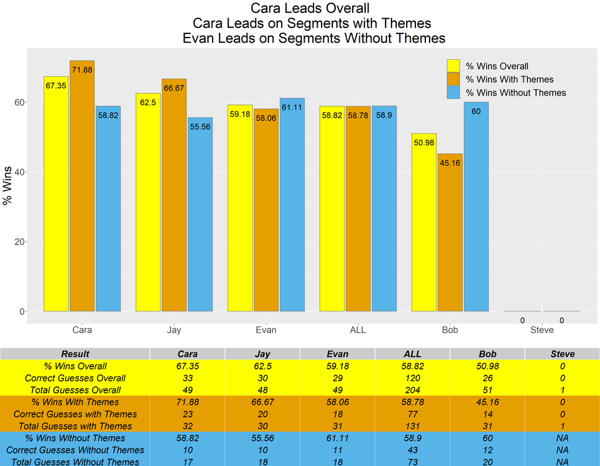

**NOTE: ALL includes contributions from Special Guest Rogues not listed**  
Raw data and some visuals are located in [This Excel file](https://github.com/wayneheller/SGU_Science_or_Fiction/blob/master/SGU_Science_or_Fiction.xlsx) Click the Download button on this github page.  
Last Year comparison is based on Episodes 756 - 807

### Overall Performance

| Panelist | 2021 | 2020 |
| --- | --- | --- |
| ALL | 59% | 57% |
| Bob | 51% | 51% |
| Cara | 67% | 65% |
| Evan | 59% | 56% |
| Jay | 62% | 56% |
| Steve | 0% | 67% |

### Performance For Segments WITH Themes

| Panelist | 2021 | 2020 |
| --- | --- | --- |
| ALL | 59% | 51% |
| Bob | 45% | 38% |
| Cara | 72% | 59% |
| Evan | 58% | 50% |
| Jay | 67% | 59% |
| Steve | 0% | 67% |

### Performance For Segments WITHOUT Themes

| Panelist | 2021 | 2020 |
| --- | --- | --- |
| ALL | 59% | 66% |
| Bob | 60% | 74% |
| Cara | 59% | 74% |
| Evan | 61% | 67% |
| Jay | 56% | 50% |

### Solo Wins

| Cara | 3 |
| --- | --- |
| Evan | 3 |
| Jay | 3 |
| Bob | 2 |
| Guest | 1 |
| TOTAL | 12 |

### Longest Consecutive Winning Streak

| Evan | 8 |
| --- | --- |
| Cara | 6 |
| Jay | 5 |
| Bob | 4 |

### Longest Consecutive Losing Streak

| Jay | 4 |
| --- | --- |
| Bob | 3 |
| Evan | 3 |
| Cara | 2 |
| Steve | 1 |

### Panel Performance When Answering First

#### A measure of how well the panel of rogues perform based on who answers first

| Panelist | 2021 | 2020 |
| --- | --- | --- |
| Jay | 54% | 63% |
| Cara | 51% | 60% |
| Evan | 58% | 50% |
| Bob | 71% | 46% |

### Individual Panelist Performance When Answering First

#### A measure of an individuals performance when answering first

| Panelist | 2021 | 2020 |
| --- | --- | --- |
| Cara | 36% | 55% |
| Evan | 31% | 44% |
| ALL | 38% | 42% |
| Jay | 30% | 38% |
| Bob | 57% | 31% |

### Host Sweeps

| Host | 2021 | 2020 |
| --- | --- | --- |
| ALL | 5 | 7 |
| Steve | 5 | 7 |

### Panelist Sweeps

#### How many times a panelist has participated in a sweep of the host

| Panelist | 2021 | 2020 |
| --- | --- | --- |
| Evan | 10 | 10 |
| Jay | 10 | 10 |
| Bob | 10 | 9 |
| Cara | 9 | 9 |
| Steve | NA | 1 |

### Duo Performance

#### How well each pair of rouges performs when choosing a DIFFERENT answer from their peer

For example, when Cara answers differently from Bob, she is correct 67% of the time.  
When Bob answers differently from Cara, he is correct 17% of the time.

| Rogue | Bob | Cara | Evan | Jay | Steve |
| --- | --- | --- | --- | --- | --- |
| Bob | NA | 17% | 35% | 38% | NA |
| Cara | 67% | NA | 47% | 53% | 100% |
| Evan | 52% | 26% | NA | 38% | 100% |
| Jay | 48% | 26% | 48% | NA | 100% |
| Steve | NA | 0% | 0% | 0% | NA |

#### How well each pair of rouges performs when choosing the SAME answer as their peer

For example, when Jay and Evan pick the same answer they are correct 83% of the time.  
Note: Numbers along the diagonal are the same as individual performance for the year.

| Rogue | Bob | Cara | Evan | Jay | Steve |
| --- | --- | --- | --- | --- | --- |
| Bob | 51% | 69% | 67% | 72% | NA |
| Cara | 69% | 67% | 81% | 88% | NA |
| Evan | 67% | 81% | 59% | 83% | NA |
| Jay | 72% | 88% | 83% | 62% | NA |
| Steve | NA | NA | NA | NA | 0% |

#### How Well Each Answering Order Combination Has Performed Since 2018

For each combination, the number of times this combination has occurred (frequency), the total correct answers, total possible answers, and the accuracy percentage (correct/possible) is listed below.

##### Answering Order Combinations with Frequency >= 3

| First | Second | Third | Fourth | Fifth | Frequency | Correct | Possible | PanelistSweeps | HostSweeps | Accuracy(%) |
| --- | --- | --- | --- | --- | --- | --- | --- | --- | --- | --- |
| Bob | Jay | Evan | Cara | NA | 7 | 23 | 28 | 4 | 0 | 82.1 |
| Cara | Evan | Jay | Bob | NA | 4 | 13 | 16 | 3 | 0 | 81.2 |
| Evan | Cara | Bob | Jay | NA | 5 | 16 | 20 | 2 | 0 | 80.0 |
| Bob | Jay | Cara | Evan | NA | 6 | 19 | 24 | 2 | 0 | 79.2 |
| Cara | Bob | Evan | Jay | NA | 9 | 28 | 36 | 4 | 0 | 77.8 |
| Cara | Jay | Evan | Bob | NA | 9 | 28 | 36 | 4 | 1 | 77.8 |
| Evan | Bob | Jay | NA | NA | 6 | 14 | 18 | 3 | 0 | 77.8 |
| Cara | Bob | Jay | Evan | NA | 5 | 14 | 20 | 1 | 0 | 70.0 |
| Evan | Bob | Jay | Cara | NA | 4 | 11 | 16 | 1 | 0 | 68.8 |
| Jay | Bob | Evan | NA | NA | 5 | 10 | 15 | 2 | 1 | 66.7 |
| Bob | Jay | Cara | NA | NA | 3 | 6 | 9 | 0 | 0 | 66.7 |
| Bob | Jay | Evan | NA | NA | 3 | 6 | 9 | 0 | 0 | 66.7 |
| Jay | Cara | Evan | Bob | NA | 3 | 8 | 12 | 0 | 0 | 66.7 |
| Bob | Evan | Cara | Jay | NA | 8 | 20 | 32 | 1 | 0 | 62.5 |
| Jay | Bob | Cara | Evan | NA | 6 | 15 | 24 | 0 | 0 | 62.5 |
| Evan | Jay | Bob | Cara | NA | 7 | 17 | 28 | 1 | 1 | 60.7 |
| Jay | Cara | Bob | Evan | NA | 3 | 7 | 12 | 0 | 0 | 58.3 |
| Jay | Evan | Cara | Bob | NA | 11 | 25 | 44 | 2 | 0 | 56.8 |
| Jay | Evan | Bob | Cara | NA | 4 | 9 | 16 | 0 | 0 | 56.2 |
| Bob | Cara | Evan | Jay | NA | 5 | 11 | 20 | 0 | 0 | 55.0 |
| Cara | Evan | Bob | Jay | NA | 5 | 11 | 20 | 1 | 1 | 55.0 |
| Evan | Cara | Jay | Bob | NA | 5 | 10 | 20 | 1 | 1 | 50.0 |
| Jay | Bob | Evan | Cara | NA | 8 | 14 | 32 | 1 | 2 | 43.8 |
| Evan | Jay | Cara | Bob | NA | 4 | 7 | 16 | 0 | 0 | 43.8 |
| Evan | Bob | Cara | Jay | NA | 9 | 15 | 36 | 0 | 1 | 41.7 |
| Jay | Bob | Cara | NA | NA | 4 | 5 | 12 | 0 | 0 | 41.7 |
| Cara | Jay | Bob | Evan | NA | 5 | 7 | 20 | 0 | 2 | 35.0 |
| Evan | Bob | Cara | NA | NA | 3 | 3 | 9 | 0 | 1 | 33.3 |

##### Answering Order Combinations Full Detail

| First | Second | Third | Fourth | Fifth | Frequency | Correct | Possible | PanelistSweeps | HostSweeps | Accuracy(%) |
| --- | --- | --- | --- | --- | --- | --- | --- | --- | --- | --- |
| Bob | Cara | Jay | NA | NA | 1 | 3 | 3 | 1 | 0 | 100.0 |
| Brian | Cara | Evan | Bob | Jay | 1 | 5 | 5 | 1 | 0 | 100.0 |
| Cara | Jay | Bob | NA | NA | 1 | 3 | 3 | 1 | 0 | 100.0 |
| George | Steve | Jay | Cara | Evan | 1 | 5 | 5 | 1 | 0 | 100.0 |
| Richard | Jay | Cara | Evan | Bob | 1 | 5 | 5 | 1 | 0 | 100.0 |
| Bob | Jay | Evan | Cara | NA | 7 | 23 | 28 | 4 | 0 | 82.1 |
| Cara | Evan | Jay | Bob | NA | 4 | 13 | 16 | 3 | 0 | 81.2 |
| Evan | Cara | Bob | Jay | NA | 5 | 16 | 20 | 2 | 0 | 80.0 |
| Bob | Jay | George | Cara | Evan | 1 | 4 | 5 | 0 | 0 | 80.0 |
| Evan | Cara | Bob | Jay | Guest | 1 | 4 | 5 | 0 | 0 | 80.0 |
| Guest | Jay | Cara | Bob | Evan | 1 | 4 | 5 | 0 | 0 | 80.0 |
| Guest | Jay | Cara | Evan | Bob | 1 | 4 | 5 | 0 | 0 | 80.0 |
| Bob | Jay | Cara | Evan | NA | 6 | 19 | 24 | 2 | 0 | 79.2 |
| Cara | Bob | Evan | Jay | NA | 9 | 28 | 36 | 4 | 0 | 77.8 |
| Cara | Jay | Evan | Bob | NA | 9 | 28 | 36 | 4 | 1 | 77.8 |
| Evan | Bob | Jay | NA | NA | 6 | 14 | 18 | 3 | 0 | 77.8 |
| Bob | Steve | Evan | Cara | NA | 1 | 3 | 4 | 0 | 0 | 75.0 |
| Guest | Evan | Jay | Bob | NA | 1 | 3 | 4 | 0 | 0 | 75.0 |
| Richard | Evan | Jay | Bob | NA | 1 | 3 | 4 | 0 | 0 | 75.0 |
| Steve | Cara | Evan | Jay | NA | 1 | 3 | 4 | 0 | 0 | 75.0 |
| Cara | Bob | Jay | Evan | NA | 5 | 14 | 20 | 1 | 0 | 70.0 |
| Bob | Cara | Jay | Evan | George | 2 | 7 | 10 | 1 | 0 | 70.0 |
| Evan | Bob | Jay | Cara | NA | 4 | 11 | 16 | 1 | 0 | 68.8 |
| Jay | Bob | Evan | NA | NA | 5 | 10 | 15 | 2 | 1 | 66.7 |
| Bob | Jay | Cara | NA | NA | 3 | 6 | 9 | 0 | 0 | 66.7 |
| Bob | Jay | Evan | NA | NA | 3 | 6 | 9 | 0 | 0 | 66.7 |
| Jay | Cara | Evan | Bob | NA | 3 | 8 | 12 | 0 | 0 | 66.7 |
| Jay | Cara | Bob | NA | NA | 1 | 2 | 3 | 0 | 0 | 66.7 |
| Jay | Evan | Bob | NA | NA | 1 | 2 | 3 | 0 | 0 | 66.7 |
| Bob | Evan | Cara | Jay | NA | 8 | 20 | 32 | 1 | 0 | 62.5 |
| Jay | Bob | Cara | Evan | NA | 6 | 15 | 24 | 0 | 0 | 62.5 |
| Bob | Cara | Jay | Evan | NA | 2 | 5 | 8 | 1 | 0 | 62.5 |
| Evan | Jay | Bob | Cara | NA | 7 | 17 | 28 | 1 | 1 | 60.7 |
| Cara | Steve | Jay | Evan | George | 1 | 3 | 5 | 0 | 0 | 60.0 |
| Jay | Cara | Bob | Evan | NA | 3 | 7 | 12 | 0 | 0 | 58.3 |
| Jay | Evan | Cara | Bob | NA | 11 | 25 | 44 | 2 | 0 | 56.8 |
| Jay | Evan | Bob | Cara | NA | 4 | 9 | 16 | 0 | 0 | 56.2 |
| Bob | Cara | Evan | Jay | NA | 5 | 11 | 20 | 0 | 0 | 55.0 |
| Cara | Evan | Bob | Jay | NA | 5 | 11 | 20 | 1 | 1 | 55.0 |
| Evan | Cara | Jay | Bob | NA | 5 | 10 | 20 | 1 | 1 | 50.0 |
| Evan | Jay | Bob | NA | NA | 2 | 3 | 6 | 1 | 1 | 50.0 |
| Steve | Bob | Jay | Cara | NA | 1 | 2 | 4 | 0 | 0 | 50.0 |
| Jay | Bob | Evan | Cara | NA | 8 | 14 | 32 | 1 | 2 | 43.8 |
| Evan | Jay | Cara | Bob | NA | 4 | 7 | 16 | 0 | 0 | 43.8 |
| Evan | Bob | Cara | Jay | NA | 9 | 15 | 36 | 0 | 1 | 41.7 |
| Jay | Bob | Cara | NA | NA | 4 | 5 | 12 | 0 | 0 | 41.7 |
| Bob | Evan | Jay | Cara | George | 1 | 2 | 5 | 0 | 0 | 40.0 |
| Evan | Jay | Cara | Bob | Marsh | 1 | 2 | 5 | 0 | 0 | 40.0 |
| Evan | Jay | George | Bob | Cara | 1 | 2 | 5 | 0 | 0 | 40.0 |
| Guest | Bob | Evan | Cara | Jay | 1 | 2 | 5 | 0 | 0 | 40.0 |
| Guest | Bob | Evan | Jay | Cara | 1 | 2 | 5 | 0 | 0 | 40.0 |
| Guest | Evan | Bob | Cara | Jay | 1 | 2 | 5 | 0 | 0 | 40.0 |
| Guest | Evan | Cara | Jay | Bob | 1 | 2 | 5 | 0 | 0 | 40.0 |
| Guest | Jay | Evan | Cara | Bob | 1 | 2 | 5 | 0 | 0 | 40.0 |
| Cara | Jay | Bob | Evan | NA | 5 | 7 | 20 | 0 | 2 | 35.0 |
| Evan | Bob | Cara | NA | NA | 3 | 3 | 9 | 0 | 1 | 33.3 |
| Cara | Evan | Bob | NA | NA | 2 | 2 | 6 | 0 | 1 | 33.3 |
| Cara | Bob | Evan | NA | NA | 1 | 1 | 3 | 0 | 0 | 33.3 |
| Evan | Jay | Cara | NA | NA | 1 | 1 | 3 | 0 | 0 | 33.3 |
| George | Bob | Steve | Cara | Jay | 1 | 2 | 6 | 0 | 0 | 33.3 |
| Guest | Jay | Evan | Bob | NA | 1 | 1 | 4 | 0 | 0 | 25.0 |
| Cara | Bob | Steve | Jay | George | 1 | 1 | 5 | 0 | 0 | 20.0 |
| Cara | Jay | Evan | Bob | Guest | 1 | 1 | 5 | 0 | 0 | 20.0 |
| Devon | Bob | Cara | Evan | Jay | 1 | 1 | 5 | 0 | 0 | 20.0 |
| George | Cara | Jay | Evan | Bob | 1 | 1 | 5 | 0 | 0 | 20.0 |
| Jay | Steve | Evan | Cara | George | 1 | 1 | 5 | 0 | 0 | 20.0 |
| Bob | Evan | Jay | Cara | NA | 2 | 1 | 8 | 0 | 1 | 12.5 |
| Bob | Cara | Jay | Evan | Bill | 1 | 0 | 5 | 0 | 1 | 0.0 |
| Bob | Evan | NA | NA | NA | 1 | 0 | 2 | 0 | 1 | 0.0 |
| Bob | Jay | Cara | George | NA | 1 | 0 | 4 | 0 | 1 | 0.0 |
| Evan | Cara | Bob | NA | NA | 1 | 0 | 3 | 0 | 1 | 0.0 |
| George | Jay | Steve | Cara | Evan | 1 | 0 | 5 | 0 | 1 | 0.0 |
| Jay | Evan | Steve | Bob | NA | 1 | 0 | 4 | 0 | 1 | 0.0 |
| Joe | Bob | Steve | Evan | NA | 1 | 0 | 4 | 0 | 1 | 0.0 |